# Data 606 FinalProject

## Part 3 - Exploratory Data Analysis

Perform relevant descriptive statistics, including summary statistics and visualization of the data. Also address what the exploratory data analysis suggests about your research question.

```r
summary(bc_data)
```

```
##        id            diagnosis  radius_mean      texture_mean
##  Min.   :     8670   B:357     Min.   : 6.981   Min.   : 9.71
##  1st Qu.:   869218   M:212     1st Qu.:11.700   1st Qu.:16.17
##  Median :   906024             Median :13.370   Median :18.84
##  Mean   : 30371831             Mean   :14.127   Mean   :19.29
##  3rd Qu.:  8813129             3rd Qu.:15.780   3rd Qu.:21.80
##  Max.   :911320502             Max.   :28.110   Max.   :39.28
##  perimeter_mean     area_mean      smoothness_mean   compactness_mean
##  Min.   : 43.79   Min.   : 143.5   Min.   :0.05263   Min.   :0.01938
##  1st Qu.: 75.17   1st Qu.: 420.3   1st Qu.:0.08637   1st Qu.:0.06492
##  Median : 86.24   Median : 551.1   Median :0.09587   Median :0.09263
##  Mean   : 91.97   Mean   : 654.9   Mean   :0.09636   Mean   :0.10434
##  3rd Qu.:104.10   3rd Qu.: 782.7   3rd Qu.:0.10530   3rd Qu.:0.13040
##  Max.   :188.50   Max.   :2501.0   Max.   :0.16340   Max.   :0.34540
##  concavity_mean    concave.points_mean symmetry_mean
##  Min.   :0.00000   Min.   :0.00000     Min.   :0.1060
##  1st Qu.:0.02956   1st Qu.:0.02031     1st Qu.:0.1619
##  Median :0.06154   Median :0.03350     Median :0.1792
##  Mean   :0.08880   Mean   :0.04892     Mean   :0.1812
##  3rd Qu.:0.13070   3rd Qu.:0.07400     3rd Qu.:0.1957
##  Max.   :0.42680   Max.   :0.20120     Max.   :0.3040
##  fractal_dimension_mean   radius_se        texture_se      perimeter_se
##  Min.   :0.04996        Min.   :0.1115   Min.   :0.3602   Min.   : 0.757
##  1st Qu.:0.05770        1st Qu.:0.2324   1st Qu.:0.8339   1st Qu.: 1.606
##  Median :0.06154        Median :0.3242   Median :1.1080   Median : 2.287
##  Mean   :0.06280        Mean   :0.4052   Mean   :1.2169   Mean   : 2.866
##  3rd Qu.:0.06612        3rd Qu.:0.4789   3rd Qu.:1.4740   3rd Qu.: 3.357
##  Max.   :0.09744        Max.   :2.8730   Max.   :4.8850   Max.   :21.980
##     area_se        smoothness_se      compactness_se      concavity_se
##  Min.   :  6.802   Min.   :0.001713   Min.   :0.002252   Min.   :0.00000
##  1st Qu.: 17.850   1st Qu.:0.005169   1st Qu.:0.013080   1st Qu.:0.01509
##  Median : 24.530   Median :0.006380   Median :0.020450   Median :0.02589
##  Mean   : 40.337   Mean   :0.007041   Mean   :0.025478   Mean   :0.03189
##  3rd Qu.: 45.190   3rd Qu.:0.008146   3rd Qu.:0.032450   3rd Qu.:0.04205
##  Max.   :542.200   Max.   :0.031130   Max.   :0.135400   Max.   :0.39600
##  concave.points_se   symmetry_se       fractal_dimension_se
##  Min.   :0.000000   Min.   :0.007882   Min.   :0.0008948
##  1st Qu.:0.007638   1st Qu.:0.015160   1st Qu.:0.0022480
##  Median :0.010930   Median :0.018730   Median :0.0031870
##  Mean   :0.011796   Mean   :0.020542   Mean   :0.0037949
```

[output cut: 8 more lines]

```
##  Max.   :36.04   Max.   :49.54   Max.   :251.20   Max.   :4254.0
##  smoothness_worst  compactness_worst concavity_worst  concave.points_worst
##  Min.   :0.07117   Min.   :0.02729   Min.   :0.0000   Min.   :0.00000
##  1st Qu.:0.11660   1st Qu.:0.14720   1st Qu.:0.1145   1st Qu.:0.06493
##  Median :0.13130   Median :0.21190   Median :0.2267   Median :0.09993
##  Mean   :0.13237   Mean   :0.25427   Mean   :0.2722   Mean   :0.11461
##  3rd Qu.:0.14600   3rd Qu.:0.33910   3rd Qu.:0.3829   3rd Qu.:0.16140
##  Max.   :0.22260   Max.   :1.05800   Max.   :1.2520   Max.   :0.29100
##  symmetry_worst   fractal_dimension_worst radius_mean_size
##  Min.   :0.1565   Min.   :0.05504         Length:569
##  1st Qu.:0.2504   1st Qu.:0.07146         Class :character
##  Median :0.2822   Median :0.08004         Mode  :character
##  Mean   :0.2901   Mean   :0.08395
##  3rd Qu.:0.3179   3rd Qu.:0.09208
##  Max.   :0.6638   Max.   :0.20750
```

```r
describe(bc_data %>% select(-id, -diagnosis))
```

```
##                         vars   n   mean     sd median trimmed    mad
## radius_mean                1 569  14.13   3.52  13.37   13.82   2.82
## texture_mean               2 569  19.29   4.30  18.84   19.04   4.17
## perimeter_mean             3 569  91.97  24.30  86.24   89.74  18.84
## area_mean                  4 569 654.89 351.91 551.10  606.13 227.28
## smoothness_mean            5 569   0.10   0.01   0.10    0.10   0.01
## compactness_mean           6 569   0.10   0.05   0.09    0.10   0.05
## concavity_mean             7 569   0.09   0.08   0.06    0.08   0.06
## concave.points_mean        8 569   0.05   0.04   0.03    0.04   0.03
## symmetry_mean              9 569   0.18   0.03   0.18    0.18   0.03
## fractal_dimension_mean    10 569   0.06   0.01   0.06    0.06   0.01
## radius_se                 11 569   0.41   0.28   0.32    0.36   0.16
## texture_se                12 569   1.22   0.55   1.11    1.16   0.47
## perimeter_se              13 569   2.87   2.02   2.29    2.51   1.14
## area_se                   14 569  40.34  45.49  24.53   31.69  13.63
## smoothness_se             15 569   0.01   0.00   0.01    0.01   0.00
## compactness_se            16 569   0.03   0.02   0.02    0.02   0.01
## concavity_se              17 569   0.03   0.03   0.03    0.03   0.02
## concave.points_se         18 569   0.01   0.01   0.01    0.01   0.01
## symmetry_se               19 569   0.02   0.01   0.02    0.02   0.01
## fractal_dimension_se      20 569   0.00   0.00   0.00    0.00   0.00
## radius_worst              21 569  16.27   4.83  14.97   15.73   3.65
## texture_worst             22 569  25.68   6.15  25.41   25.39   6.42
## perimeter_worst           23 569 107.26  33.60  97.66  103.42  25.01
## area_worst                24 569 880.58 569.36 686.50  788.02 319.65
## smoothness_worst          25 569   0.13   0.02   0.13    0.13   0.02
## compactness_worst         26 569   0.25   0.16   0.21    0.23   0.13
## concavity_worst           27 569   0.27   0.21   0.23    0.25   0.20
## concave.points_worst      28 569   0.11   0.07   0.10    0.11   0.07
## symmetry_worst            29 569   0.29   0.06   0.28    0.28   0.05
## fractal_dimension_worst   30 569   0.08   0.02   0.08    0.08   0.01
## radius_mean_size*         31 569    NaN     NA     NA     NaN     NA
##                            min     max   range skew kurtosis    se
## radius_mean               6.98   28.11   21.13 0.94     0.81  0.15
## texture_mean              9.71   39.28   29.57 0.65     0.73  0.18
## perimeter_mean           43.79  188.50  144.71 0.99     0.94  1.02
## area_mean               143.50 2501.00 2357.50 1.64     3.59 14.75
## smoothness_mean           0.05    0.16    0.11 0.45     0.82  0.00
## compactness_mean          0.02    0.35    0.33 1.18     1.61  0.00
## concavity_mean            0.00    0.43    0.43 1.39     1.95  0.00
```

[output cut: 9 more lines]

```
## concavity_se              0.00    0.40    0.40 5.08    48.24  0.00
## concave.points_se         0.00    0.05    0.05 1.44     5.04  0.00
## symmetry_se               0.01    0.08    0.07 2.18     7.78  0.00
## fractal_dimension_se      0.00    0.03    0.03 3.90    25.94  0.00
## radius_worst              7.93   36.04   28.11 1.10     0.91  0.20
## texture_worst            12.02   49.54   37.52 0.50     0.20  0.26
## perimeter_worst          50.41  251.20  200.79 1.12     1.04  1.41
## area_worst              185.20 4254.00 4068.80 1.85     4.32 23.87
## smoothness_worst          0.07    0.22    0.15 0.41     0.49  0.00
## compactness_worst         0.03    1.06    1.03 1.47     2.98  0.01
## concavity_worst           0.00    1.25    1.25 1.14     1.57  0.01
## concave.points_worst      0.00    0.29    0.29 0.49    -0.55  0.00
## symmetry_worst            0.16    0.66    0.51 1.43     4.37  0.00
## fractal_dimension_worst   0.06    0.21    0.15 1.65     5.16  0.00
## radius_mean_size*          Inf    -Inf    -Inf   NA       NA    NA
```

```r
table(bc_data$diagnosis)
```

```
##
##   B   M
## 357 212
```

Boxplots of the 10 mean variables vs. diagnosis:

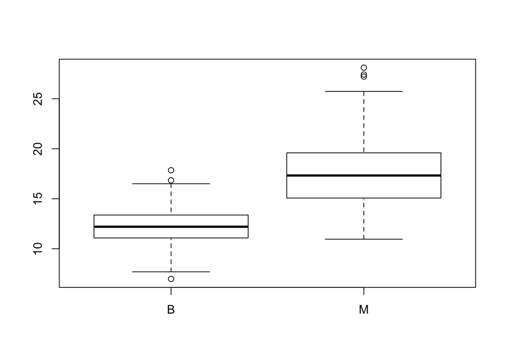

```r
boxplot(radius_mean ~ diagnosis, data = bc_data)
```

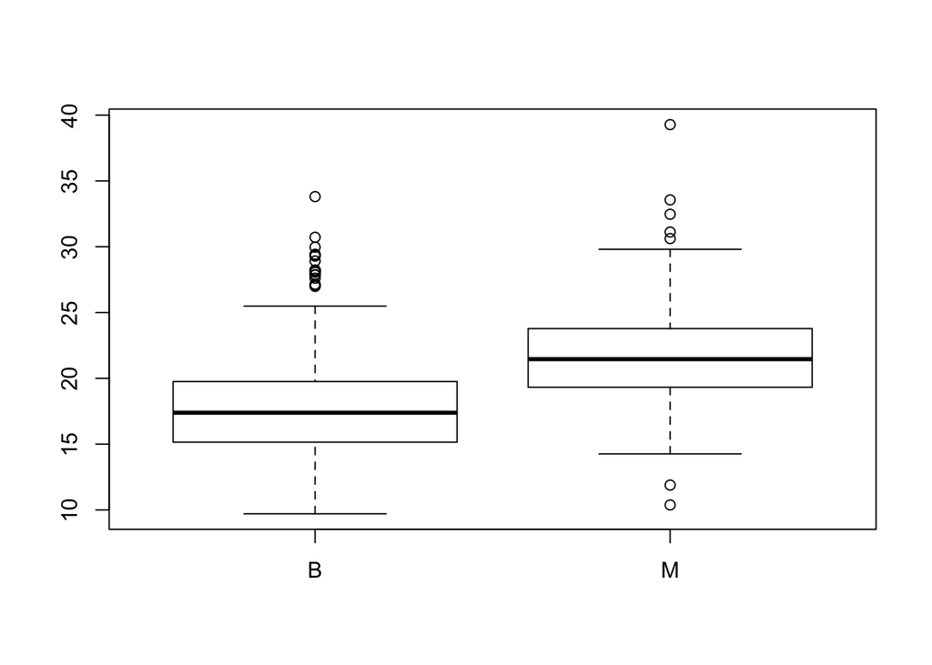

```r
boxplot(texture_mean ~ diagnosis, data = bc_data)
```

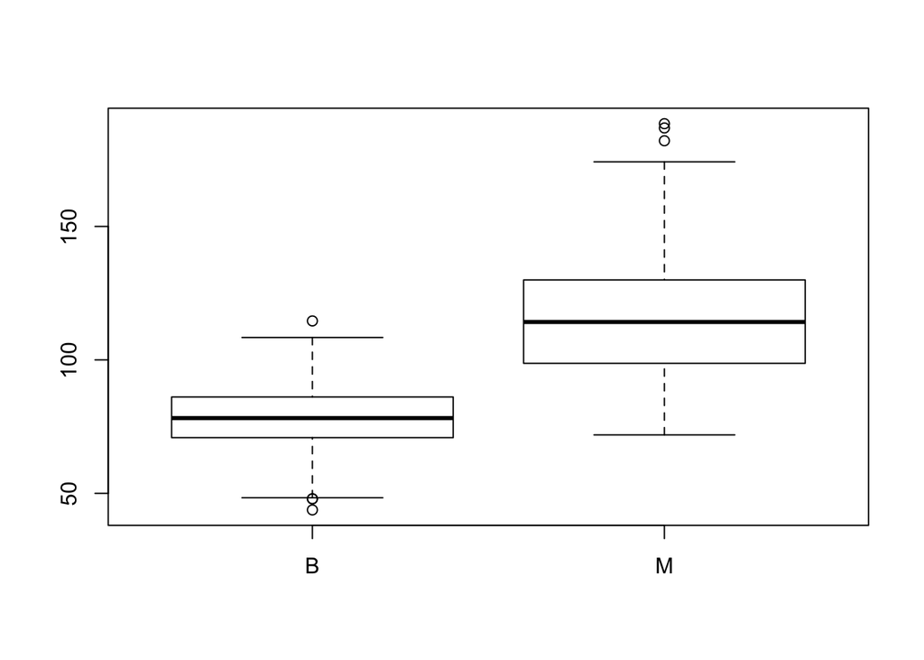

```r
boxplot(perimeter_mean ~ diagnosis, data = bc_data)
```

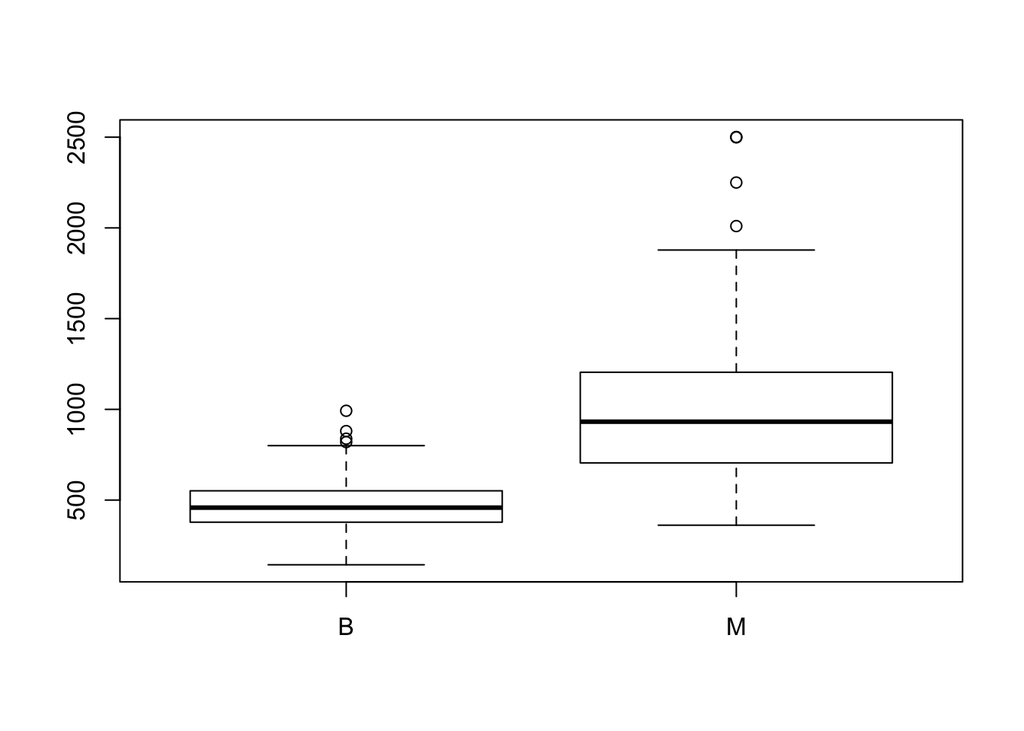

```r
boxplot(area_mean ~ diagnosis, data = bc_data)
```

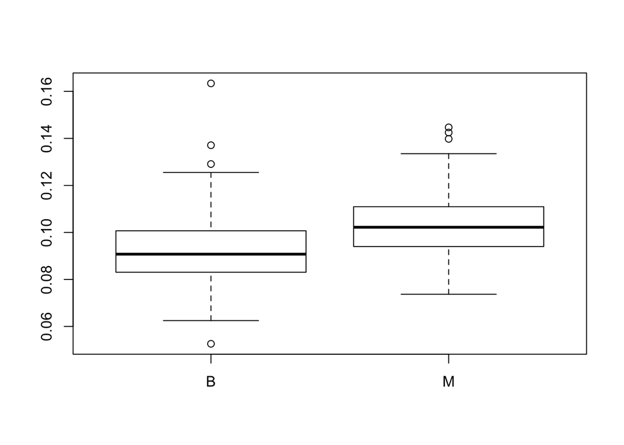

```r
boxplot(smoothness_mean ~ diagnosis, data = bc_data)
```

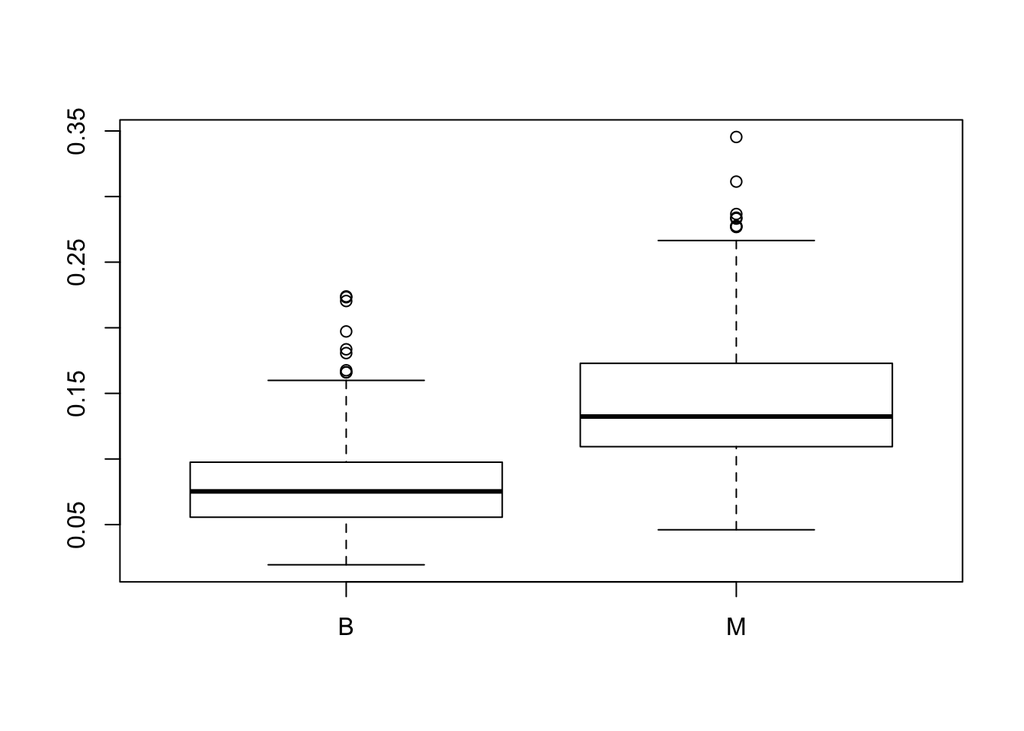

```r
boxplot(compactness_mean ~ diagnosis, data = bc_data)
```

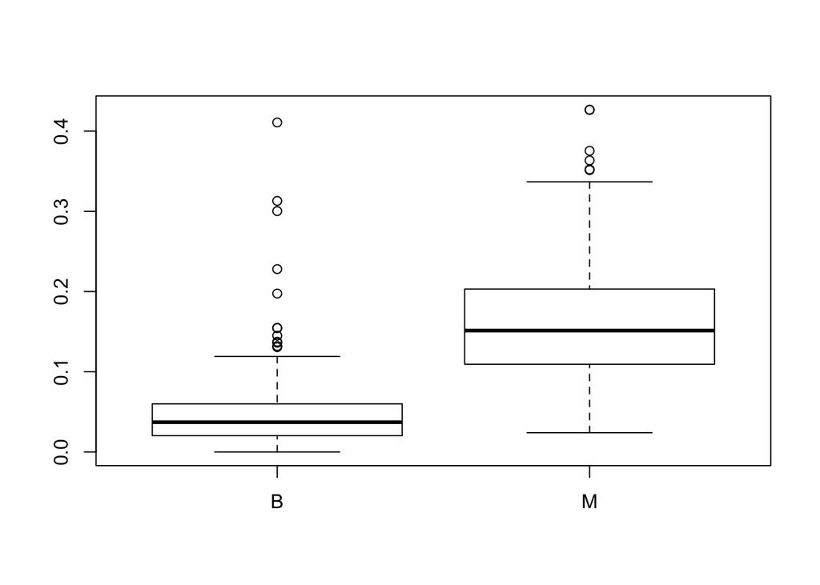

```r
boxplot(concavity_mean ~ diagnosis, data = bc_data)
```

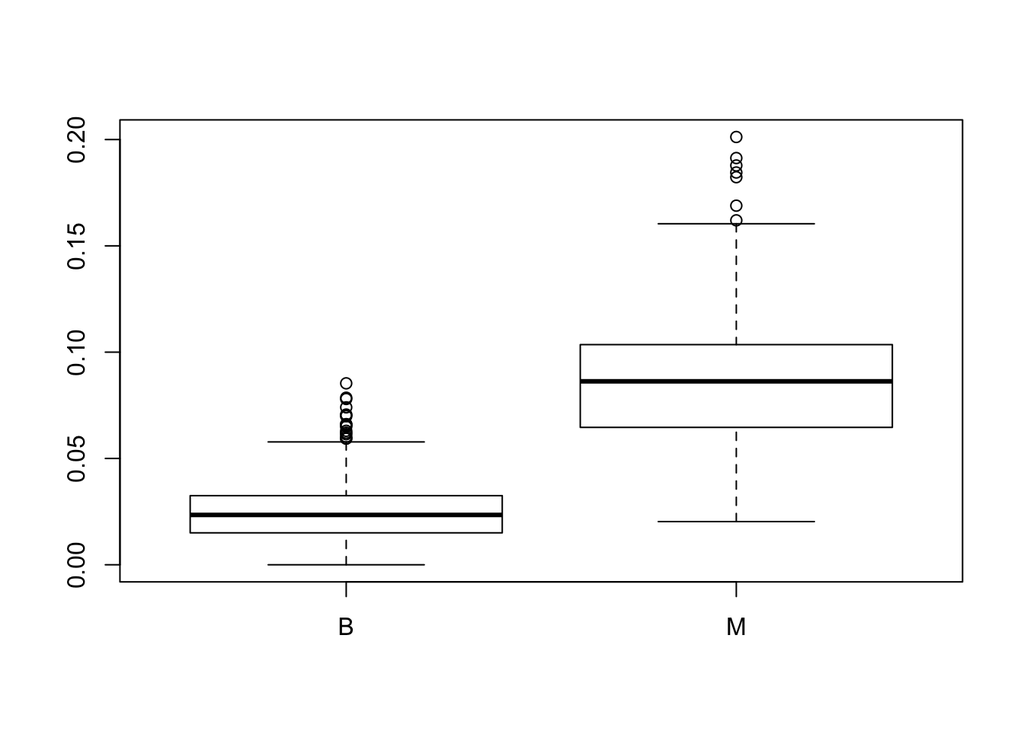

```r
boxplot(concave.points_mean ~ diagnosis, data = bc_data)
```

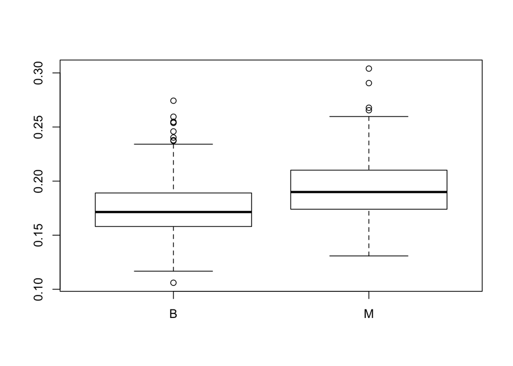

```r
boxplot(symmetry_mean ~ diagnosis, data = bc_data)
```

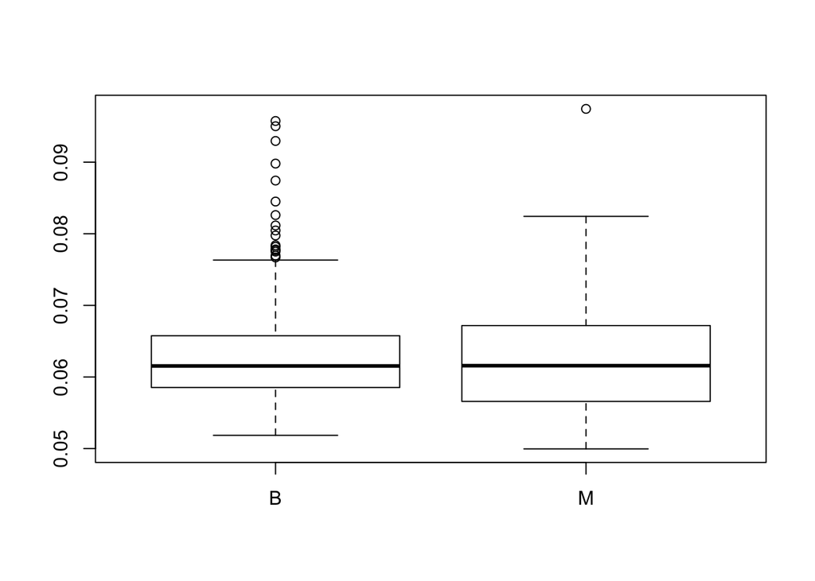

```r
boxplot(fractal_dimension_mean ~ diagnosis, data = bc_data)
```

## Part 4 - Inference

If your data fails some conditions and you can’t use a theoretical method, then you should use simulation. If you can use both methods, then you should use both methods. It is your responsibility to figure out the appropriate methodology.

### Check conditions

Conditions for Regression:

- The residuals of the model are nearly normal
- The variability of the residuals is nearly constant
- The residuals are independent
- Each variable is linearly related to the outcome

### Theoretical inference (if possible) -

```r
#bc_model <- lm()
```

### Brief description of methodology that reflects your conceptual understanding

## Part 5 - Conclusion

### References

This database is also available through the UW CS ftp server: ftp ftp.cs.wisc.edu cd math-prog/cpo-dataset/machine-learn/WDBC/

Also can be found on UCI Machine Learning Repository: https://archive.ics.uci.edu/ml/datasets/Breast+Cancer+Wisconsin+%28Diagnostic%29

Dua, D. and Karra Taniskidou, E. (2017). UCI Machine Learning Repository [http://archive.ics.uci.edu/ml]. Irvine, CA: University of California, School of Information and Computer Science.

Creators:

1. Dr. William H. Wolberg, General Surgery Dept. University of Wisconsin, Clinical Sciences Center Madison, WI 53792 wolberg ‘@’ eagle.surgery.wisc.edu
2. W. Nick Street, Computer Sciences Dept. University of Wisconsin, 1210 West Dayton St., Madison, WI 53706 street ‘@’ cs.wisc.edu 608-262-6619
3. Olvi L. Mangasarian, Computer Sciences Dept. University of Wisconsin, 1210 West Dayton St., Madison, WI 53706 olvi ‘@’ cs.wisc.edu